# Annotation Report

Virulence genes annotated using VFDB and Victors databases

Ecoli genome assembly

29 março 2020

# About

Virulence factors are molecules produced by bacteria that add effectiveness in their colonization of a niche, immunoevasion, immunosuppression and obtain nutrition from the host.

[VFDB](http://www.mgc.ac.cn/VFs/main.htm) (Virulence Factor Database) is a comprehensive resource, created in 2004, of curated information about virulence factors of pathogenic bacteria. To date, it contains a 1080 virulence factors in its database, from 74 *bacteria genera*.

[Victors](http://www.phidias.us/victors/) is a curated database which currently possesses 5296 virulence factors for 194 different pathogens including bacteria, viruses and parasites.

[VFDB](http://www.mgc.ac.cn/VFs/main.htm) and [Victors](http://www.phidias.us/victors/) databases were blasted via BLASTx, using the thresholds below. This report summarizes its results.

- Blast % identity: `> 95%`
- Blast % query coverage: `> 95%`

# Results

## VFDB

A summary of all the virulence factors which had at least on gene found in the query genome is shown in the figure below (Figure 1. Virulence genes are more detailed in Table below. It shows the gene product, source and name of each gene related to a Virulence Factor found in the query genome. The annotation shown is linked to the database for further investigations.

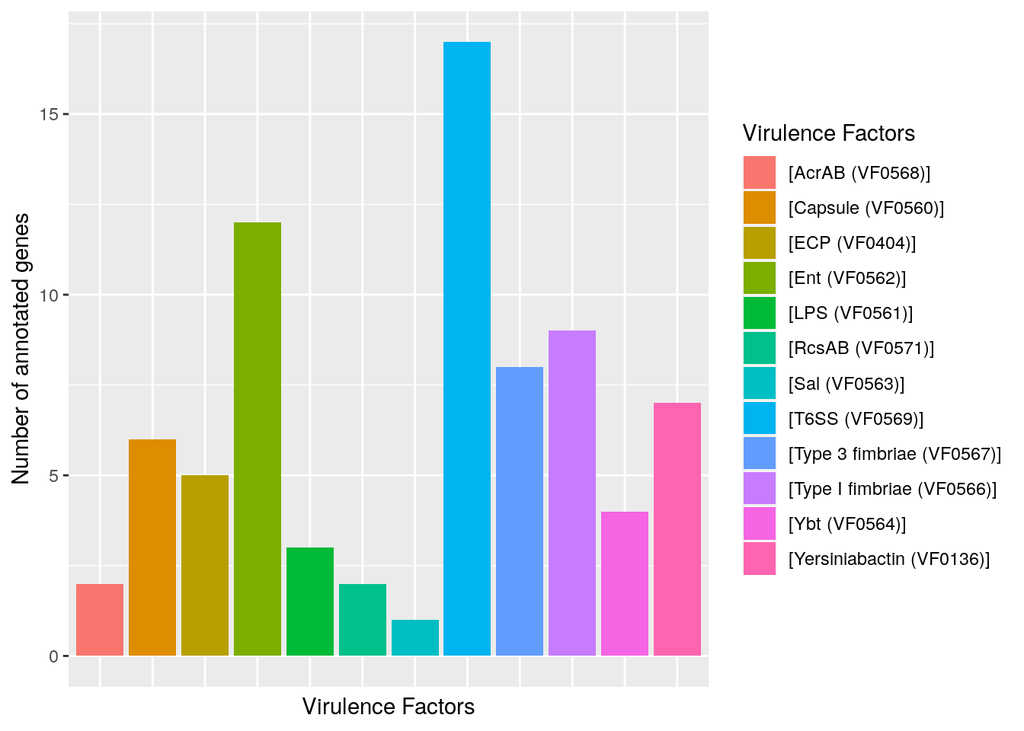

Figure 1: Virulence Factors annotated from [VFDB](http://www.mgc.ac.cn/VFs/main.htm) database

### Supporting data

| Virulence Factor Name | VF ID | Gene Name | Description | Subject Species | Query Protein ID | Query Protein Coordinates |
| --- | --- | --- | --- | --- | --- | --- |
| [AcrAB (VF0568)] | VFG049133(gb\|YP_002918166.1) | (acrA) | acriflavine resistance protein A | [Klebsiella pneumoniae subsp. pneumoniae NTUH-K2044] | AENPOJHA_01740 | gnl\|UnB\|AENPOJHA_8:27672-28865 |
| [AcrAB (VF0568)] | VFG049144(gb\|YP_002918165.1) | (acrB) | acriflavine resistance protein B | [Klebsiella pneumoniae subsp. pneumoniae NTUH-K2044] | AENPOJHA_01741 | gnl\|UnB\|AENPOJHA_8:28888-32034 |
| [Capsule (VF0560)] | VFG048797(gb\|YP_002920350.1) | (ugd) | UDP-glucose 6-dehydrogenase | [Klebsiella pneumoniae subsp. pneumoniae NTUH-K2044] | AENPOJHA_05127 | gnl\|UnB\|AENPOJHA_60:8639-9805 |
| [Capsule (VF0560)] | VFG048808(gb\|YP_002920351.1) | (manB) | phosphomannomutase | [Klebsiella pneumoniae subsp. pneumoniae NTUH-K2044] | AENPOJHA_05132 | gnl\|UnB\|AENPOJHA_60:13578-14948 |
| [Capsule (VF0560)] | VFG048819(gb\|YP_002920352.1) | (manC) | mannose-1-phosphate guanylyltransferase | [Klebsiella pneumoniae subsp. pneumoniae NTUH-K2044] | AENPOJHA_05133 | gnl\|UnB\|AENPOJHA_60:14970-16385 |
| [Capsule (VF0560)] | VFG048830(gb\|YP_002920353.1) | (gnd) | 6-phosphogluconate dehydrogenase | [Klebsiella pneumoniae subsp. pneumoniae NTUH-K2044] | AENPOJHA_05134 | gnl\|UnB\|AENPOJHA_60:16612-18018 |
| [Capsule (VF0560)] | VFG048972(gb\|YP_002920366.1) | (wza) | capsule polysaccharide export protein precursor | [Klebsiella pneumoniae subsp. pneumoniae NTUH-K2044] | AENPOJHA_05396 | gnl\|UnB\|AENPOJHA_84:2151-3287 |
| [Capsule (VF0560)] | VFG048980(gb\|YP_002920367.1) | (wzi) | surface assembly of capsule | [Klebsiella pneumoniae subsp. pneumoniae NTUH-K2044] | AENPOJHA_05395 | gnl\|UnB\|AENPOJHA_84:575-2008 |
| [ECP (VF0404)] | VFG002412(gb\|NP_286009) | (yagY/ecpB) | E. coli common pilus chaperone EcpB | [Escherichia coli O157:H7 str. EDL933] | AENPOJHA_01893 | gnl\|UnB\|AENPOJHA_8:185538-186206 |
| [ECP (VF0404)] | VFG002413(gb\|NP_286011) | (ykgK/ecpR) | regulator protein EcpR | [Escherichia coli O157:H7 str. EDL933] | AENPOJHA_01895 | gnl\|UnB\|AENPOJHA_8:186927-187469 |

[output cut: 66 more lines]

## Victors

A summary of all the virulence factors which had at least on gene found in the query genome is shown in the Table below. The results are presented with gene name, gene product, genomics coordinates, query protein name and database ID. The annotation shown is linked to the database for further investigations.

| Query Protein ID | Gene Name | Product | Database ID | Query Protein Coordinates |
| --- | --- | --- | --- | --- |
| AENPOJHA_03593 | arcA | two-component response regulator | 1135 | gnl\|UnB\|AENPOJHA_22:37254-37970 |
| AENPOJHA_01306 | tktA | transketolase | 2065 | gnl\|UnB\|AENPOJHA_5:158195-160186 |
| AENPOJHA_00118 | pyrD | dihydroorotate dehydrogenase 2 | 2120 | gnl\|UnB\|AENPOJHA_1:130770-131780 |
| AENPOJHA_03403 | phoU | transcriptional regulator PhoU | 2122 | gnl\|UnB\|AENPOJHA_20:34268-34993 |
| AENPOJHA_02343 | mglA | galactose/methyl galaxtoside transporter ATP-binding protein | 2130 | gnl\|UnB\|AENPOJHA_11:114161-115681 |
| AENPOJHA_01849 | rdgC | recombination associated protein | 2134 | gnl\|UnB\|AENPOJHA_8:142357-143268 |
| AENPOJHA_01297 | serA | D-3-phosphoglycerate dehydrogenase | 2164 | gnl\|UnB\|AENPOJHA_5:148433-149665 |
| AENPOJHA_02648 | nrdD | anaerobic ribonucleoside triphosphate reductase | 2171 | gnl\|UnB\|AENPOJHA_13:95252-97390 |
| AENPOJHA_03825 | ilvG | acetolactate synthase 2 catalytic subunit | 2179 | gnl\|UnB\|AENPOJHA_25:3761-5407 |
| AENPOJHA_01571 | narG | nitrate reductase 1, alpha subunit | 2180 | gnl\|UnB\|AENPOJHA_7:48886-52629 |

[output cut: 20 more lines]